# 2022 flux data analysis

initial analyses: flux data, Newfoundland CA, 2022

```r
library(lmerTest)
library(DHARMa)
library(sjstats)
library(sjPlot)
library(tidyverse)
```

I want to build a linear mixed-effects model with flux as the response variable and: 1) treatment as a fixed effect 2) transect location as a fixed effect 3) transect number (1-3) as a nested random effect within site ((1|site/transect))

I’ll need to include other variables: 1) ambient temperature 2) soil moisture 3) light level 4) chamber temperature

H1: there is a difference in flux rates across collars/coverage level - higher fluxes in the gaps - lower fluxes in the mature canopy H2: flux rates differ between the two treatment (gap provenance) types - higher fluxes in timber gaps than in insect gaps - greater variability in insect gaps than in timber gaps

```r
fluxdat5 %>%
  filter(disturbance != "exclosure" & disturbance != "control") %>% # if plotting collar data
  ggplot(aes(x=Lflux_dry))+
  geom_density(color = "black", fill = "dodgerblue", alpha = 0.25)+
  # facet_grid(~collar)+
  facet_grid(~disturbance)+
  xlab(~paste("flux, ", mu, "mol m"^-2,"s"^-1))+
  theme_classic()+
  geom_vline(data = mn_flux_coverage,
  # geom_vline(data = mn_flux_collar,
             aes(xintercept = mean,
                 # color = collar))+
            color = coverage))
```

[output not shown]

Plot the flux data across treatment and location:

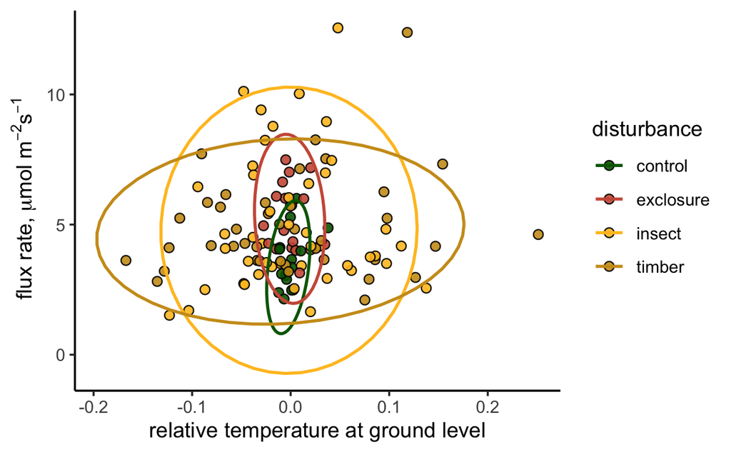

```r
fluxdat5 %>%
  ggplot(aes(x=rel_chmbrT, y=Lflux_dry, color = disturbance))+
  # ggplot(aes(x=rel_chmbrT, y=rel_flux, color = disturbance))+
  # geom_smooth(method = "lm", se = F)+
  geom_point(size = 2, shape = 21, color = "black", alpha = .9,
             aes(fill = disturbance))+
  xlab("relative temperature at ground level")+
  # ylab(~paste("relative flux rate, ", mu, "mol m"^-2,"s"^-1))+
  ylab(~paste("flux rate, ", mu, "mol m"^-2,"s"^-1))+
  # ylim(-5,13)+
  stat_ellipse(size = 0.75)+
  scale_fill_manual(values = c("control" = "darkgreen",
                               "exclosure" = "coral3",
                               "insect" = "goldenrod1",
                               "timber" = "goldenrod3"))+
  scale_color_manual(values = c("control" = "darkgreen",
                               "exclosure" = "coral3",
                               "insect" = "goldenrod1",
                               "timber" = "goldenrod3"))+
  theme_classic()
```

Plot with moose population density:

[figure not shown]

```r
fluxdat_noexcl %>%
  filter(disturbance != "control") %>%
  # filter(coverage == "open") %>%
  ggplot(aes(x=altitude, y=Lflux_dry, fill = density))+
  geom_point(position = "jitter", size = 4, shape = 21, colour = "black")+
  ylab(~paste("flux rate, ", mu, "mol m"^-2,"s"^-1))+xlab("altitude (m)")+
  scale_fill_continuous(type = "viridis")+
  theme_classic()
```

[output not shown]

Correlation (correlelogram) between selected variables in the dataset (including moose density):

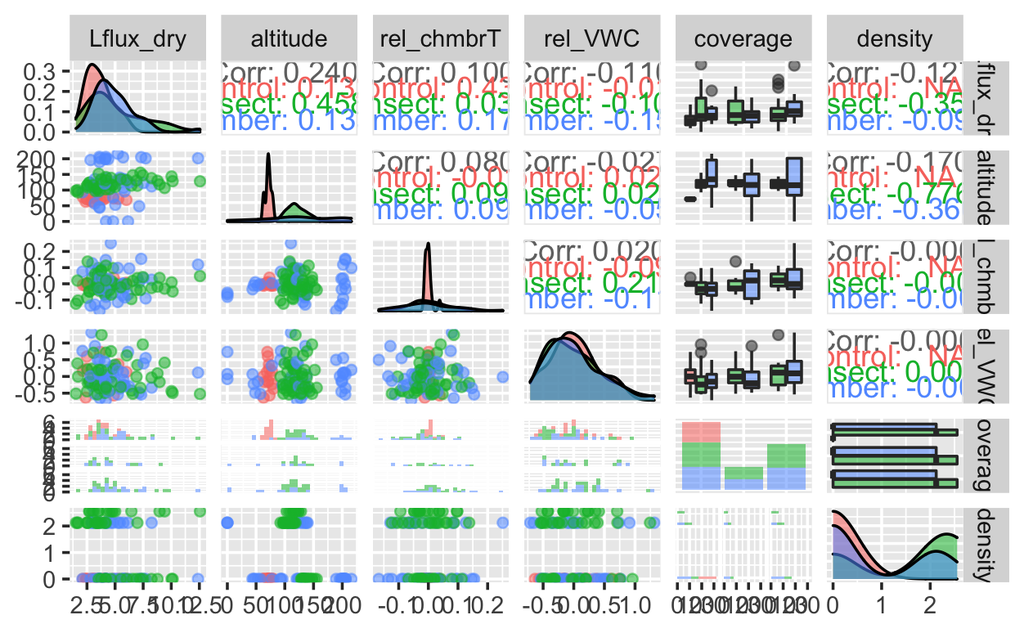

Next start to add first-level predictors: site-level predictors. visualize them first:

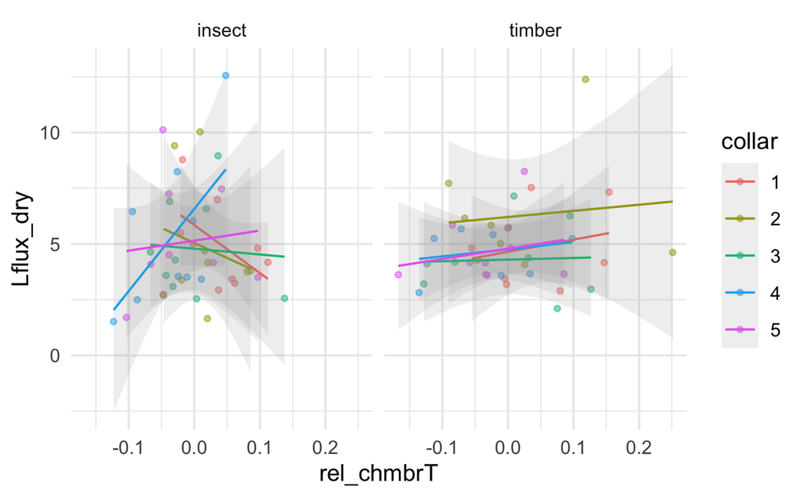

moose vs. carbon flux:

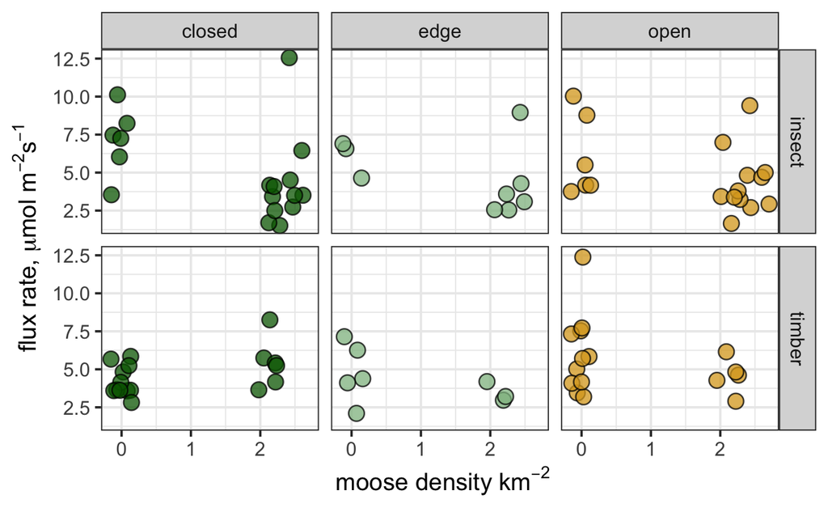

Heili notes: “also organic layer depth prob is correlated with location - if i had to guess” “are your models flux ~ temp + location? unless you think it’s really driving things, i think this is the story you want to get across” - avg. organic layer depth is correlated with collar/coverage - temps across the board are correlated - final model should be much simpler to preserve power and not overfit aka flux ~ chamber/coverage - is it overfitting to include soil or chamber T in the final model, if those are correlated with collar location? (yes)